# Exercise solution for Chapter 8, Part 1

Burton Karger

2020-04-30

# Vocabulary for Chapter 12

Sherry WeMott

2020-05-04

### Exercise 8.1

> **edgeR.** Do the analyses of Section 8.5 with the `edgeR` package and compare the results: make a scatterplot of the log 10 p-values, pick some genes where there are large differences, and visualize the raw data to see what is going on. Based on this can you explain the differences?

First we load our libraries.

```r
library(pasilla)
library(edgeR)
library(dplyr)
library(DESeq2)
library(ggplot2)
library(pheatmap)
library(tidyverse)
```

We will use the same data used in the `DESeq2` examples from the section 8.5.

Load the example data using the `system.file` call for R data stored as part of a R package. Subsequent conversion to a matrix object.

```r
fn = system.file("extdata", "pasilla_gene_counts.tsv",
                  package = "pasilla", mustWork = TRUE)
counts = as.matrix(read.csv(fn, sep = "\t", row.names = "gene_id"))

head(counts)
```

```
##             untreated1 untreated2 untreated3 untreated4 treated1 treated2
## FBgn0000003          0          0          0          0        0        0
## FBgn0000008         92        161         76         70      140       88
## FBgn0000014          5          1          0          0        4        0
## FBgn0000015          0          2          1          2        1        0
## FBgn0000017       4664       8714       3564       3150     6205     3072
## FBgn0000018        583        761        245        310      722      299
##             treated3
## FBgn0000003        1
## FBgn0000008       70
## FBgn0000014        0
## FBgn0000015        0
## FBgn0000017     3334
## FBgn0000018      308
```

### EdgeR

Now begins the same analysis with the `edgeR` package. To do this we follow the vignette for the package that is a downloadable .pdf file that you can get in your Rstuio `vignette("edgeR")` or online https://www.bioconductor.org/packages/release/bioc/vignettes/edgeR/inst/doc/edgeRUsersGuide.pdf.

```r
group <- factor(c(1,1,1,1,2,2,2))
x <- DGEList(counts=counts, group=group)
```

Calculate normalization factors to scale the raw library sizes.

```r
x <- calcNormFactors(x)
x
```

```
## An object of class "DGEList"
## $counts
##             untreated1 untreated2 untreated3 untreated4 treated1 treated2
## FBgn0000003          0          0          0          0        0        0
## FBgn0000008         92        161         76         70      140       88
## FBgn0000014          5          1          0          0        4        0
## FBgn0000015          0          2          1          2        1        0
## FBgn0000017       4664       8714       3564       3150     6205     3072
##             treated3
## FBgn0000003        1
## FBgn0000008       70
## FBgn0000014        0
## FBgn0000015        0
## FBgn0000017     3334
## 14594 more rows ...
##
## $samples
##            group lib.size norm.factors
## untreated1     1 13972512    0.9995731
## untreated2     1 21911438    1.0081519
## untreated3     1  8358426    0.9843974
## untreated4     1  9841335    0.9525077
## treated1       2 18670279    1.0651817
## treated2       2  9571826    0.9957012
## treated3       2 10343856    0.9978557
```

```r
design <- model.matrix(~group)
design
```

```
##   (Intercept) group2
## 1           1      0
## 2           1      0
## 3           1      0
## 4           1      0
## 5           1      1
## 6           1      1
## 7           1      1
## attr(,"assign")
## [1] 0 1
## attr(,"contrasts")
## attr(,"contrasts")$group
## [1] "contr.treatment"
```

The `estimateDisp` function “Maximizes the negative binomial likelihood to give the estimate of the common, trended and tagwise dispersions across all tags. Usage”. We have to use this negative bionmial (aka gamma-Poisson) model since our experiments vary from replicate to replicate more than the traditional Poisson can account for. These varaiances can be due seemingly miniscule experimental conditions such as, temperatue of cell culture, pipettor calibration, etc. In the case of the gamma-Poisson we have two inputs for variance and mean instead of just having $\lambda$ for both variance and mean in the normal Poisson.

```r
design_matrix <- estimateDisp(x, design)
design_matrix
```

```
## An object of class "DGEList"
## $counts
##             untreated1 untreated2 untreated3 untreated4 treated1 treated2
## FBgn0000003          0          0          0          0        0        0
## FBgn0000008         92        161         76         70      140       88
## FBgn0000014          5          1          0          0        4        0
## FBgn0000015          0          2          1          2        1        0
## FBgn0000017       4664       8714       3564       3150     6205     3072
##             treated3
## FBgn0000003        1
## FBgn0000008       70
## FBgn0000014        0
## FBgn0000015        0
## FBgn0000017     3334
## 14594 more rows ...
##
## $samples
##            group lib.size norm.factors
## untreated1     1 13972512    0.9995731
## untreated2     1 21911438    1.0081519
## untreated3     1  8358426    0.9843974
## untreated4     1  9841335    0.9525077
## treated1       2 18670279    1.0651817
## treated2       2  9571826    0.9957012
## treated3       2 10343856    0.9978557
##
## $design
##   (Intercept) group2
## 1           1      0
## 2           1      0
## 3           1      0
## 4           1      0
## 5           1      1
## 6           1      1
## 7           1      1
## attr(,"assign")
## [1] 0 1
## attr(,"contrasts")
## attr(,"contrasts")$group
## [1] "contr.treatment"
```

[output cut: 13 more lines]

```
## $AveLogCPM
## [1] -2.636763  2.953356 -1.966526 -2.223010  8.454625
## 14594 more elements ...
##
## $trend.method
## [1] "locfit"
##
## $prior.df
## [1] 5.886884
##
## $prior.n
## [1] 1.177377
##
## $span
## [1] 0.3013916
```

Now that we have our `design_matrix` we can begin fitting modified linear models to it. Here we use a quasi-likelihood negative binomial generalized log-linear model, which is a mouth full. “Quasi-likelihood estimation is one way of allowing for overdispersion, that is, greater variability in the data than would be expected from the statistical model used.” Since we have already stated that we will have variation in our experiments due to the most minute factors this issue of overdisperision is apparent. Instead of using a traditional probility function, a variance function is used (variance as a function of the mean) and allows for an overdispersion parameter input which is used to to “fix” the variance function to resemble that of an exisiting probility function (ex.Poisson).

```r
fit <- glmQLFit(design_matrix, design)
qlf <- glmQLFTest(fit, coef=2)
edgeRoutput <- topTags(qlf)
```

Now we want to visualize the data points after their regression fits. We must tidy up the data sets a bit to apply some `Tidyverse` magic.

```r
tidy_pasilla <- pasilla %>%
  results() %>%
  as.data.frame() %>%
  rownames_to_column(var = "gene_id") %>%
  select(gene_id, pvalue, padj) %>%
  arrange(desc(padj))

tidy_edgeR <- qlf %>%
  as.data.frame() %>%
  rownames_to_column(var = "gene_id") %>%
  select(gene_id, PValue)
```

Using `full_join` from `dplyr` package we are able to subset these two dataframes based on the `gene_id` column and keeping all matching columns.

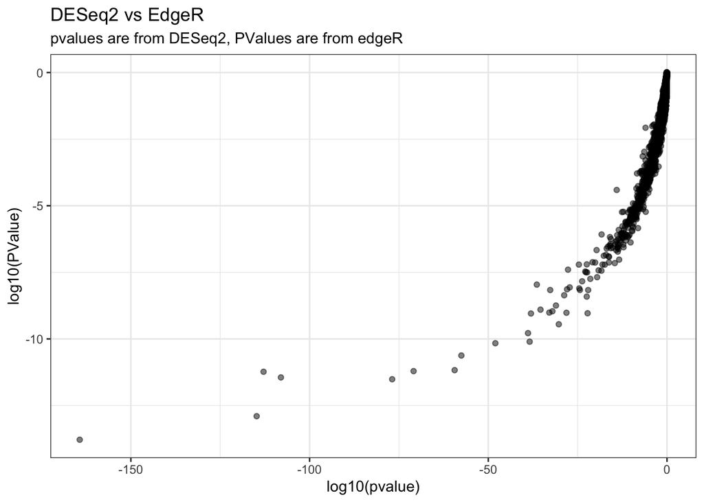

```r
full_join(tidy_pasilla, tidy_edgeR,
          "gene_id") %>%
  ggplot(aes(x = log10(pvalue), y = log10(PValue))) +
  geom_point(alpha = 0.5) +
  ggtitle("DESeq2 vs EdgeR", subtitle = "pvalues are from DESeq2, PValues are from edgeR") +
  theme_bw()
```

So below we subset the data again, this time selecting those points with pvalue < -25 (log10 values). When plotting these we don’t see any overlapping, showing that there are some variations between the `edgeR` and `DESeq2` packages.

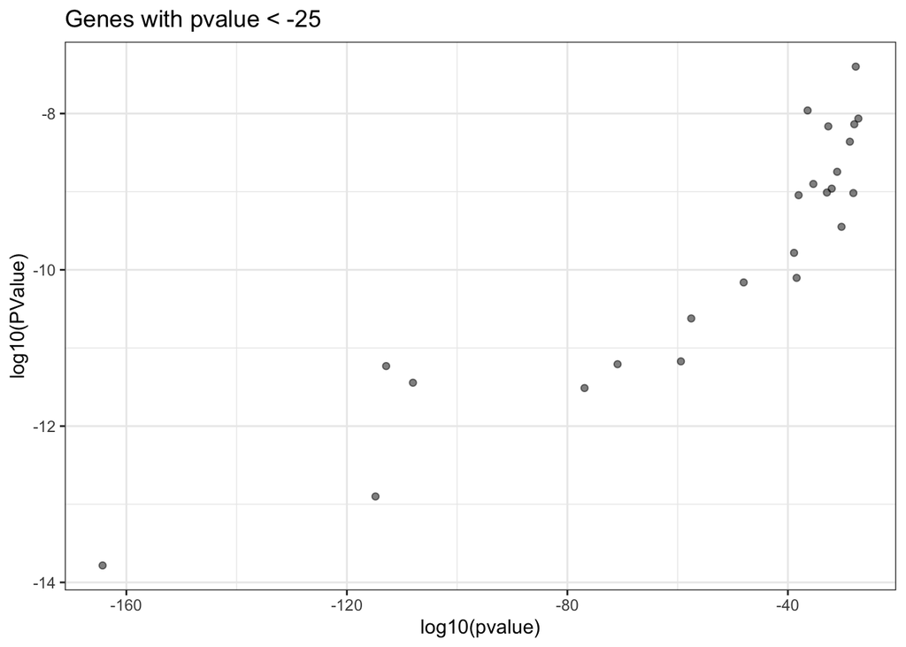

```r
full_join(tidy_pasilla, tidy_edgeR,"gene_id") %>%
  filter(log10(pvalue) <= -25) %>%
  ggplot(aes(x = log10(pvalue), y = log10(PValue))) +
  geom_point(alpha = 0.5) +
  ggtitle("Genes with pvalue < -25") +
  theme_bw()
```

### References

- https://www.bioconductor.org/packages/release/bioc/vignettes/edgeR/inst/doc/edgeRUsersGuide.pdf
- https://en.wikipedia.org/wiki/Quasi-likelihood
- http://web.stanford.edu/class/bios221/book/Chap-CountData.html
- https://rstudio.com/wp-content/uploads/2015/02/rmarkdown-cheatsheet.pdf
- https://geanders.github.io/RProgrammingForResearch/

Chapter 12 covers supervised learning and the statistics of predicting categorical variables. Also discussed are the issues of overfitting and generalizability and how to “train” statistical models.

| predictors | charactersics measured for an observation that may be useful in predicting the target variable |
| --- | --- |
| overfitting | the production of an analysis that corresponds too closely or exactly to a particular set of data, and may therefore fail to fit additional data or predict future obervations reliably |
| generalization | refers to how well the concepts learned by a machine learning model apply to specific examples not seen by the model when it was learning |
| statistical learning | framework for machine learning drawing from the fields of statistics and functional analysis. Deals with the problem of finding a predictive function based on data |
| objective response | in the context of supervised learning, a measurable response |
| kernel methods | class of algorithms for pattern analysis, whose best known member is the support vector machine (SVM). These use kernel functions, which enable them to operate in a high-dimensional, implicit feature … |
| regression | statistical method that attempts to determine the strength and character of the relationship between one dependent variable (usually denoted by Y) and a series of other variables (known as independent… |
| classification | the process of grouping observations in a dataset by their similarities in terms of measured characteristics |
| linear discriminant analysis (LDA) | a common technique used both for supervised learning classification and as a pre-processing dimension reduction step that finds a linear combination of features to help in classification |
| misclassification rate (MCR) | in regards to statistical learning, the fraction of times the prediction is wrong, specifically when relating to classification of models |
| leave-one out cross-validation | k-fold cross validation taken to its logical extreme, with K equal to N, the number of data points in the set |
| k-fold cross-validation | a technique where observations are repeatedly split into a training set of size around n(k-1)/k and a test set of size of around n/k. Mainly used in prediction when one wants to estimate how accuratel… |
| curse of dimensionality | refers to the fact that high-dimensional spaces are very hard, if not impossible, to sample thoroughly, because data in any particular region becomes very sparse as dimensions increase |
| confusion table | in the field of machine learning and specifically the problem of statistical classification, a specific table layout that allows visualization of the performance of an algorithm, typically a supervise… |
| sensitvity | true positivity rate or recall, measures the proportion of actual positives that are correctly identified as such |
| specificity | true negative rate, the probability, measures the proportion of actual negatives that are correctly identified as negative |
| receiver operating characteristic(ROC)/precision recall curve | a graphical plot that illustrates the diagnostic ability of a binary classifier system as its discrimination threshold is varied |
| Jaccard index | a statistic used in quantifying the similarities between sample sets, which is formally defined as the size of the intersection between two sets divided by the size of the union of the sets |
| mean-squared error (MSE) | the average squared error |
| risk function/cost function/objective function | the function that you optimize during the training of a predictive model (e.g., the maximum likelihood function for a classic regression model) |
| bias | a measure of how different the average of all the different estimates is from the truth |
| variance | how much an individual estimate might scatter from the average value |
| penalization | a tool to actively control and exploit the variance-bias tradeoff |
| regularization | a method used to to ensure stable estimates by helping to prevent overfitting of the model to the training data |
| logistic regression | a statistical model that in its basic form uses a logistic function to model a binary dependent variable. A binary logistic model has a dependent variable with two possible values (e.g, healthy/sick) … |
| penalty function | a term added to the objective function that consists of a penalty parameter multiplied by a measure of violation of the constraints |
| ridge regression | a method of regression in which the cost function is altered by adding a penalty equivalent to square of the magnitude of the coefficients. Doing this shrinks coefficients and helps reduce model compl… |
| lasso | in the context of statistical regression modeling, Least Absolute Shrinkage and Selection Operator that is used in one type of regression modeling to reduce over-fitting and select useful features of … |
| elastic net | in the fitting of linear or logistic regression models, a regularized regression method that linearly combines the L1 and L2 penalties of the lasso and ridge methods |
| ExperimentalHub | in the context of Bioconductor, provides a central location where curated data from experiments, publications or training courses can be accessed |
| kingdom | the second highest taxonomic rank, just below domain |
| phylum | a level of classification of taxonomic rank below kingdom and above class |
| species | the basic unit of classification and a taxonomic rank of an organism, as well as unit of biodiversity |
| diagnostic plots | statistical influence plots that help to visualize how well a model fits the data (e.g. Normal Q-Q, Residuals vs Fitted) |
| tuning parameters | parameters that control the strength of the penalty term in certain types of regression algorithms (e.g., ridge and lasso regression), controlling the amount of shrinkage (where parameter estimates ar… |
| p-value hacking | manipulation of the data until finding a statistic that yields a desired result |
| workflow | in the context of a computational analysis, the chaining of software tools together in a series of steps that operate on data |
| scale invariance | a feature of objects or laws that do not change if scales, length, energy, or other variables, are multiplied by a common factor, and thus represent universality |

### Sources consulted or cited

*Some of the definitons above are based in part or whole on listed definitions in the following source:*

Holmes and Huber, 2019. *Modern Statistics for Modern Biology.* Cambridge University Press, Cambridge, United Kingdom.

https://en.wikipedia.org/

https://machinelearningmastery.com/overfitting-and-underfitting-with-machine-learning-algorithms/

https://.statisticshowto.com

https://www.cs.cmu.edu/~schneide/tut5/node42.html

https://towardsdatascience.com

https://bioconductor.org

https://pfern.gtihub.io

### Practice

[interactive chart not shown]